# Final Project Experimenting

Preliminary Exploratory Data Analysis

Jesse Quijano

2024-11-10

# What Continent has the most meteorite strikes by quantity and volume?

### Set Up

#### Clean up environment and load packages:

```r
rm(list = ls())
library(tidyverse)

#install.packages("maps")
```

## The Data Sets

The primary data set I will use is from The National Aeronautics and Space Administration (NASA).

Each case, 45,716 in total, represents a meteorite that has “landed” on Earth. There are three primary variables I am interested in (at least for now):

- reclat - the latitude of where the meteorite was found.
- reclong - the longitude of where the metorite was found.
- mass - the weight in grams of the meteorite

The other data set is from Dtechtive. It’s the first I found, but is now just serving as my back-up data. I’d like to find a way to link that data between this and the NASA data, but haven’t found a reliable join as of yet.

```r
data <- read.csv("Meteorite_Landings_20241109.csv")
head(data)
```

|  | name | id | nametype | recclass | mass..g. | fall | year | reclat | reclong | GeoLocation |
| --- | --- | --- | --- | --- | --- | --- | --- | --- | --- | --- |
| 1 | Aachen | 1 | Valid | L5 | 21 | Fell | 1880 | 50.77500 | 6.08333 | (50.775, 6.08333) |
| 2 | Aarhus | 2 | Valid | H6 | 720 | Fell | 1951 | 56.18333 | 10.23333 | (56.18333, 10.23333) |
| 3 | Abee | 6 | Valid | EH4 | 107000 | Fell | 1952 | 54.21667 | -113.00000 | (54.21667, -113.0) |
| 4 | Acapulco | 10 | Valid | Acapulcoite | 1914 | Fell | 1976 | 16.88333 | -99.90000 | (16.88333, -99.9) |
| 5 | Achiras | 370 | Valid | L6 | 780 | Fell | 1902 | -33.16667 | -64.95000 | (-33.16667, -64.95) |
| 6 | Adhi Kot | 379 | Valid | EH4 | 4239 | Fell | 1919 | 32.10000 | 71.80000 | (32.1, 71.8) |

```r
rejects <- data %>% filter(is.na(reclong))

#install.packages("foreign")
library(foreign)
dbf <- read.dbf("cartodb_query.dbf") #another meteorite data set that might be useful as it contains links out to meteoritical society
head(dbf)
```

|  | place | type_of_me | mass_g | fell_found | year | database | coordinate | coordina_1 | cartodb_id | created_at | updated_at | year_date |
| --- | --- | --- | --- | --- | --- | --- | --- | --- | --- | --- | --- | --- |
| 1 | Ur | Iron | 0.00 | Found | -2500 | http://www.lpi.usra.edu/meteor/metbull.php?code=24125 | 30.9 | 46.01667 | 34242 | 2013-02-15 | 2013-02-15 |  |
| 2 | A-881561 | H4 | 836.87 | Found | 1988 | http://www.lpi.usra.edu/meteor/metbull.php?code=4270 | -72 | 26 | 4141 | 2013-02-15 | 2013-02-15 | 1988-01-01 |
| 3 | Wietrzno-Bobrka | Iron | 376.00 | Found | -600 | http://www.lpi.usra.edu/meteor/metbull.php?code=24259 | 49.41667 | 21.7 | 6037 | 2013-02-15 | 2013-02-15 |  |
| 4 | A-881448 | H4 | 341.27 | Found | 1988 | http://www.lpi.usra.edu/meteor/metbull.php?code=4157 | -72 | 26 | 6340 | 2013-02-15 | 2013-02-15 | 1988-01-01 |
| 5 | A-881813 | L6 | 296.96 | Found | 1988 | http://www.lpi.usra.edu/meteor/metbull.php?code=4522 | -72 | 26 | 6753 | 2013-02-15 | 2013-02-15 | 1988-01-01 |
| 6 | A-881637 | L3 | 195.62 | Found | 1988 | http://www.lpi.usra.edu/meteor/metbull.php?code=4346 | -72 | 26 | 8147 | 2013-02-15 | 2013-02-15 | 1988-01-01 |

!! More information on the NASA data can be found at [NASA: Meteorite Landings](https://data.nasa.gov/Space-Science/Meteorite-Landings/gh4g-9sfh/about_data)

## Experiment Using `rworldmap` to Find Continent Names

The other data set I will definitely be using. Leveraging geo coordinates (lat/long) from a sample meteorite landing, see if I can find the corresponding country data - specifically the continent, but there seems to be some other interesting data I might be able to make use of.

```r
# will use this to convert the lat/long to continent
# Information found here: https://stackoverflow.com/a/14342127/1732853

library(sp)
#install.packages("rworldmap")
library(rworldmap)
vignette("rworldmap")
help("rworldmap")

countriesSP <- getMap(resolution='low')
head(countriesSP)

test_points <- data.frame(longitude = c(6.08333), latitude = c(50.77500))

pointsSP = SpatialPoints(test_points, proj4string=CRS(proj4string(countriesSP)))
indices = over(pointsSP, countriesSP)
indices
indices$REGION # will for sure need this!

coords_to_continent = function(points)
{
  print(points)
  countriesSP <- getMap(resolution='low')

  pointsSP = SpatialPoints(points, proj4string=CRS(proj4string(countriesSP)))
  indices = over(pointsSP, countriesSP)
  indices$REGION # will for sure need this!
}

coords_to_continent(test_points)
```

[output not shown]

## Let’s see if we can plot the data on the world map

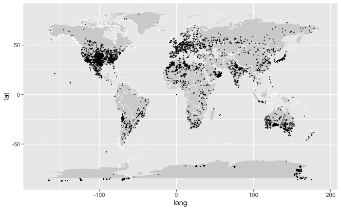

```r
glyph_ready <- data %>%
  filter(!is.na(reclong), reclong <= 180, reclong >= -180) %>%
  mutate(continent = coords_to_continent(data.frame(longitude = c(reclong), latitude = c(reclat)))) %>%
  select(lat = reclat, long = reclong, continent, weight = mass..g.)

world <- map_data("world")

ggplot() +
  geom_map(
    data = world, map = world,
    aes(long, lat, map_id = region), color = "white", fill = "lightgray", linewidth = 0.1
  ) +
  geom_point(
    data = glyph_ready,
    aes(long, lat), #, color = by type maybe?
    alpha = 0.7,
    size = .1
  )
```

## Fun with population

https://r2country.obi.obianom.com/

## More data experimentation

```r
data %>% group_by(recclass) %>% summarize(total = n()) %>% arrange(desc(total))
```

| recclass | total |
| --- | --- |
| L6 | 8285 |
| H5 | 7142 |
| L5 | 4796 |
| H6 | 4528 |
| H4 | 4211 |
| LL5 | 2766 |
| LL6 | 2043 |
| L4 | 1253 |
| H4/5 | 428 |
| CM2 | 416 |

[output cut: 456 more lines]

```r
data %>% group_by(year) %>% summarize(total = n()) %>% arrange(desc(year))
```

| year | total |
| --- | --- |
| 2101 | 1 |
| 2013 | 11 |
| 2012 | 234 |
| 2011 | 713 |
| 2010 | 1005 |
| 2009 | 1497 |
| 2008 | 957 |
| 2007 | 1189 |
| 2006 | 2456 |
| 2005 | 875 |

[output cut: 256 more lines]